# The green halo: Mechanisms and limits of the eco-label effect - ScienceDirect

## [Food Quality and Preference](https://www.sciencedirect.com/journal/food-quality-and-preference)

[Volume 43](https://www.sciencedirect.com/journal/food-quality-and-preference/vol/43/suppl/C), July 2015, Pages 1-9

# The green halo: Mechanisms and limits of the eco-label effect

[Patrik Sörqvist <sup>a</sup>](https://www.sciencedirect.com/author/15822744100/patrik-sorqvist), , , , , , , [John E. Marsh <sup>a</sup> <sup>c</sup>](https://www.sciencedirect.com/author/7401946238/john-e-marsh)

https://doi.org/10.1016/j.foodqual.2015.02.001[Get rights and content](https://s100.copyright.com/AppDispatchServlet?publisherName=ELS&contentID=S0950329315000312&orderBeanReset=true)

Under a Creative Commons [license](http://creativecommons.org/licenses/by-nc-nd/4.0/)

Open access

## Highlights

- •

  Fruit tastes better when called “eco-friendly” (an eco-label effect).
- •

  The eco-label effect extends to other judgmental dimensions beside taste.
- •

  The magnitude of the effect varies with product type and judgmental dimension.
- •

  Various accounts of the eco-label effect are discussed.
- •

  The eco-label effect is not caused by [social desirability](https://www.sciencedirect.com/topics/social-sciences/social-desirability).

## Abstract

Consumers believe that “eco-labeled” products taste better, which, at least in part, may be an effect of the label. The purpose of the current series of experiments was to examine some mechanisms and limits of this eco-label effect. In Experiment 1, an eco-label effect of similar magnitude was found for taste ratings of both conventional and organic bananas. Experiment 2 showed eco-label effects for a wider range of judgmental dimensions (i.e., health, calories, vitamins/minerals, mental performance, and willingness to pay) and the effect was about the same in magnitude for judgments of grapes and raisins. Experiment 3, with water as the tasted product, found no eco-label effect on judgments of taste, calories and vitamins/minerals, but an effect on willingness to pay, judgments of health benefits and judgments of mental performance benefits. Experiments 2 and 3 also included questionnaires on social desirability traits, schizotypal traits and pro-environmental consumer traits. The last was the strongest predictor of the eco-label effect amongst the three. In all, the eco-label effect is a robust phenomenon, but depends on interactions between product type and judgmental dimension. Implications for several accounts of the effect are discussed.

## Keywords

Eco-label effect

Organic

Eco-friendly

Social desirability

Schizotypy

Pro-environmental consumer behavior

## 1. Introduction

While some view the marketing of organic products as nothing but “green-washing” (Chen and Chang, 2012, Dahl, 2010)—the deceptive promotion of the perception that an organization’s products and policy aims are indeed environmentally friendly—current evidence suggests that eco-friendly [agriculture](https://www.sciencedirect.com/topics/agricultural-and-biological-sciences/agricultural-science) is an important step in the attempt to save our planet from the threats of environmental disaster (El-Hage Scialabba and Müller-Lidenlauf, 2010, Gattinger et al., 2012). For example, the conventional banana industry is one of the most noxious agricultural industries and involves large volumes of toxic pesticides, harming workers, wildlife and tropical environments in general (Henriques et al., 1997, Wesseling et al., 1996). The societal, political and environmental gains of a more eco-friendly and socially responsible [food production](https://www.sciencedirect.com/topics/social-sciences/food-production) are substantial. Against this background, an important scientific endeavor is to identify potential advantages of eco-friendly farming that may appeal to consumers and make eco-friendly products more attractive than conventional alternatives in the grocery stores.

The evidence in support for an advantage in eco-friendly products is mixed. Although some health benefits from organic food have been shown in fruit flies (Chhabara, Kolli, & Bauer, 2013), the general picture is that eco-friendly foods do not seem to be more nutritious than their conventional counterparts (Dangour et al., 2010, Smith-Spangler et al., 2012), with [dairy products](https://www.sciencedirect.com/topics/food-science/dairy-product) being a notable exception (Palupi, Jayanegara, Ploegera, & Kahl, 2012). One possible health benefit of eco-friendly food is reduced exposure to pesticides (Barański et al., 2014, Lu et al., 2006, Smith-Spangler et al., 2012), which consumers seem to be aware of (Williams & Hammitt, 2001), but whether eco-friendly food actually is safer to consume is still debatable (Curl et al., 2003, Magkos et al., 2006, Worthington, 2001). Another important quality dimension on which eco-friendly and conventional food appears to differ is taste. Consumers do say they prefer the taste of eco-friendly food over ordinary food products (Fillion and Arazi, 2002, Grankvist and Biel, 2001, Theuer, 2006), including organic bananas (Basker, 1992). Chemical analyses also indicate that organically produced bananas actually differ from conventional bananas. In particular, organic bananas contain less moisture, fructose and glucose and more sucrose (Forster, Rodriguez, & Romero, 2002) and they also differ in mineral content (Nyanjage, Wainwright, Bishop, & Cullum, 2001). These chemical differences speak for a production effect on taste evaluations (i.e., that organically grown products have better taste than conventionally grown products due to production differences) and could explain why there is a general taste preference for organic bananas.

However, just calling a product “eco-friendly” is enough to make people believe it tastes better than an objectively identical alternative. Because of this, it is unclear why consumers prefer the taste of eco-friendly products. In a recent set of experiments, Sörqvist et al. (2013) asked participants to taste two cups of coffee. The cups actually contained identical coffee, although the participants were told that one cup contained “eco-friendly” coffee and that the other did not. A systematic taste-preference bias for the eco-friendly alternative was revealed, especially in participants with a generally positive view toward eco-friendly consumer behavior. The participants were also willing to pay more for the “eco-friendly” coffee, especially those who preferred the taste of it. Similar findings have also been reported for wine (Wiedmann, Hennigs, Behrens, & Klarmann, 2014) as well as for [potato chips](https://www.sciencedirect.com/topics/agricultural-and-biological-sciences/potato-chips) and yoghurt, although the eco-label had the opposite effect for cookies (Lee, Shimizu, Kniffin, & Wansink, 2013). One possibility is that eco-labels can be associated with poor quality in some products, whereby the magnitude of the eco-label effect is modulated and the direction even reversed. Together, these results point toward the same conclusion: An eco-label tends to enhance the taste [sensory evaluation](https://www.sciencedirect.com/topics/agricultural-and-biological-sciences/sensory-evaluation) of consumable products.

Label effects arise even if there is no reasonable relation between the product label and what is being evaluated about the product, a form of glorification (so-called halo effects). For example, people believe that chocolate claimed to be fair-trade is healthier (Schuldt, Muller, & Schwartz, 2012) and tastes better (Lotz, Chrisandl, & Fetchenhauer, 2013) than non-labeled alternatives. The reasons for this might be self-fulfilling expectations. People form expectations about future events and their expectations guide attention (Nöstl, Marsh, & Sörqvist, 2012), shape sensory perception (Deliza & MacFie, 1996) and modulate how the stimulus input is perceptually classified (de Araujo, Rolls, Velazco, Margot, & Cayeux, 2005). For example, if people expect they will be registering a smell of “cheddar cheese”, the odor, upon presentation, is rated as more pleasant and activates different brain areas than if people would be expecting the smell of “body odor” instead (de Araujo et al., 2005). Moreover, informational framing appears to have its effect on the actual taste experience; the label effects are not just reflecting biases in self-reports (Litt & Shiv, 2012). The preference bias for eco-labeled products over objectively identical but conventionally labeled alternatives could be caused by similar expectation processes modulating the actual sensory experiences (e.g., Sörqvist et al., 2013). This can be called a distorted perceptions account of the eco-label effect. The overarching purpose of the current series of experiments is to study the mechanisms and limits of the eco-label effect.

## 2. Experiment 1

Experiment 1 addressed one limit of the eco-label effect: It explored whether the effect arises in both “organic” and “conventional” exemplars of the same fruit even though they differ in taste. If, for example, the eco-label effect only arises for conventionally grown bananas (that may be expected to have inferior taste to organically grown bananas based on the findings of Basker (1992)), but not for organically grown bananas, then the taste of the product appears to modulate when the eco-label effect becomes manifest. Thus, Experiment 1 differs from all other studies, to date, that have examined the eco-label effect on taste (Lee et al., 2013, Sörqvist et al., 2013, Wiedmann et al., 2014), in that previous studies only have compared taste evaluations of identical products (e.g., two cups of identical, organic coffee) wherein one of them is called “eco-friendly” and the other is called “conventional”. In similar settings, there is no actual taste difference between the two products and, therefore, it is impossible to know from these studies whether the eco-label effect becomes manifest across different exemplars of the same food that differ in taste. As a solution to this extant shortcoming, we had people taste both conventionally grown and eco-friendly bananas. The bananas were labeled either “conventional” or “eco-friendly”, but in half of the taste samples the label did not correspond with the actual type of banana.

## 3. Methods

### 3.1. Participants

Forty-eight Swedish individuals (11 males and 37 females, mean age = 27 years, range 18–56 years) participated in the study after informed consent. All participants received a chocolate bar as gratitude for their participation. The study was approved by the Uppsala regional ethical review board (Dnr 2013/132). As the data was treated confidentially, and no apparent ethical research complication with participation could be identified, oral consent was deemed sufficient by the ethical review board. The data collectors took note of the oral consent.

### 3.2. Materials

Products that are certified for being environmentally friendly are labeled “eco-friendly” (“Ekologisk” or “Kravmärkt”) in Sweden, not “organic” (see Klintman & Boström, 2004, for an extended discussion), but the meaning of the two labels is very similar. Because of this, we use the words “organic” and “eco-friendly” interchangeably in this paper. Both the organic/eco-friendly and conventional bananas used in this study were of the type called *Cavendish*, because it is the most commonly grown banana specie and chemical differences between organically grown and conventional Cavendish bananas has been documented (Nyanjage et al., 2001). To assure, as far as practically possible, that the two types of banana had reached the same state in the maturation process, the selected eco-friendly and conventional bananas were very similar in color and size, and the slices looked approximately identical. A [pilot](https://www.sciencedirect.com/topics/economics-econometrics-and-finance/aviation-employees) experiment with 4 participants was conducted, using the same taste estimate scale as in the experiment proper (see below). In the pilot experiment, the participants tasted a single sample of an organic banana and a single sample of a conventional banana, and there were no labels (i.e., it was a blind test). The pilot confirmed that there was a noticeable taste difference between the two types of banana. Because of this, a taste difference between the two types of banana was expected in the experiment proper as well.

### 3.3. Design and procedure

The experiment took place on a university campus. People passing by the test site were recruited as participants and were told that the experiment was about taste of eco-friendly and conventional bananas. The participants tasted four different banana slices, sliced up on four different plates. Each slice was approximately 0.5–1.0 cm thick. Potential browning, due to air exposure, was controlled by removing any part of the banana that was exposed to air and not serving this to the participants. The slices that were served to the participants were cut just prior to tasting. Two plates were marked “eco-friendly” and two were marked “conventional”. One slice from an eco-friendly banana was placed on a plate marked “eco-friendly” and one slice from the same banana was placed on the plate marked “conventional”, and vice versa for a conventional banana. The first slice of banana that each participant tasted was assigned a 6 on a taste scale that spanned from 1 (not good) to 11 (very good). The participants were told that the first banana served as a comparison point for subsequent taste ratings. The purpose of this procedure was to reduce error variance and to promote that all of the participants would use the same strategy (to compare the bananas) when making the taste estimates. The participants were then asked to rate the taste of each of the three subsequent bananas, respectively, on the same scale 1–11, by answering the question: “How good do you think the banana tastes?” (The exact wording in Swedish was: “Hur god tycker du att bananen är?”). Each taste estimate was made immediately after tasting each slice, respectively. The taste order of the four banana slices was counterbalanced between participants.

## 4. Results and discussion

As can be seen in Fig. 1, the bananas received higher taste ratings when they were called “eco-friendly” than when they were called “conventional”. Hence, the eco-label effect was replicated. Moreover, the magnitude of the eco-label effect was slightly larger when the label was attached to a conventional banana, but the difference in the magnitude of the eco-label effect between organically grown and conventionally grown bananas was not statistically significant. The results also uncovered a potential production effect—that organically grown bananas taste better than conventionally grown bananas, regardless of label. These conclusions were confirmed by a 2(type of banana: eco-friendly vs. conventional) × 2(label: eco-friendly vs. conventional) repeated measures [analysis of variance](https://www.sciencedirect.com/topics/food-science/analysis-of-variance) (Table 1). As the frequentists approach cannot provide any likelihood for the null hypothesis, [Bayesian](https://www.sciencedirect.com/topics/economics-econometrics-and-finance/bayesian) inference was conducted to investigate the lack of interaction between Type and Label. The analysis revealed a [Bayes Factor](https://www.sciencedirect.com/topics/psychology/bayes-factor) of 4.2 (i.e., positive evidence for the null-hypothesis). The important conclusion from Experiment 1, for our purposes here, is that the eco-label effect becomes manifest in both organic and conventional bananas, even though they differ in average taste values (irrespective of label).

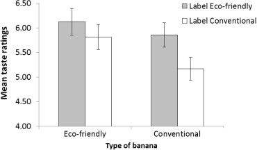

Fig. 1. Average taste ratings for all four banana categories: eco-labeled eco-friendly bananas, conventional-labeled eco-friendly bananas, eco-labeled conventional bananas and conventional-labeled conventional bananas. Error bars represent standard error of means.

Table 1. Results from the 2(type of banana: eco-friendly vs. conventional) × 2(label: eco-friendly vs. conventional) repeated measures [analysis of variance](https://www.sciencedirect.com/topics/food-science/analysis-of-variance).

| Effect | *df* | *F* | *p* | *η<sub>p</sub>*<sup>2</sup> |
| --- | --- | --- | --- | --- |
| Type | 1, 47 | 4.94 | .031 | .10 |
| Label | 1, 47 | 8.06 | .007 | .15 |
| Type × label | 1, 47 | 0.99 | .325 | .02 |

The potential production effect—greater taste ratings attributed to organically produced bananas regardless of label—is consistent with a study by Basker (1992) and may spark interest in future research to examine the taste differences between organically grown and conventionally grown fruits and vegetables in the context of blind tests. A prerequisite for drawing any conclusion about the potential benefits of organic production processes is, however, that extraneous variables that may potentially influence taste experiences are carefully controlled.

## 5. Experiment 2

Experiment 2 was designed to further test the limits of the eco-label effect. This was achieved by two means. First, we tested whether the effect would become manifest in a wider range of judgmental dimensions than in previous studies which have found the effect for sensory judgments (e.g., taste), nutrition judgments (e.g., calories) and value-related judgments (e.g., willingness to pay) (Lee et al., 2013, Sörqvist et al., 2013). In Experiment 2, we tested whether the eco-label effect also generalizes to judgments of benefits for mental abilities and aimed to characterize the health related halo effect in eco-labeled products by using one general dimension (i.e., healthiness) and two specific dimensions (i.e., vitamins/minerals and calories). The main purpose of introducing judgments of benefits for mental abilities was to address whether the eco-label effect also kicks in for judgments that depend more on abstract pre-conceptions and beliefs prior to the experiment (like benefits for mental abilities) than on tangible product characteristics.

Second, Experiment 2 also explored how the magnitude of the effect differs—if at all—for products which are clearly distinguished in terms of taste, chewiness, moisture, texture and other sensory variables. To this end, we chose two different fruit: grapes and raisins (i.e., dried grapes). The advantage of choosing these products is that many extraneous variables are controlled, as grapes and raisins are relatively similar, unlike, for example, two products such as cookies and yoghurt. Thus, grapes and raisins make it easier to draw reliable conclusions about the role played by product characteristics.

Experiment 2 was also designed to investigate the potential mechanisms underpinning the eco-label effect. One factor that may question the validity of the eco-label effect as reflecting real differences in sensory perception and/or the participants’ “true views” is [social desirability](https://www.sciencedirect.com/topics/social-sciences/social-desirability) (i.e., people’s tendency to behave in ways that are approved by others). Indeed, to prefer eco-labeled products is regarded as socially desirable by society (Félonneau and Becker, 2008, Oerke and Bogner, 2013) and therefore it is reasonable to suspect that the eco-label effect is, at least in part, a consequence of social desirability (more specifically a consequence of impression management, a deceptive attempt to appear as if one holds attitudes and behaviors that are approved by others, upon making the product estimates). One way to test this hypothesis is to request participants to fill in a [social desirability scale](https://www.sciencedirect.com/topics/psychology/social-desirability-scale) (Rudmin, 1999) that is designed to identify participants who respond in a socially desirable, but untruthful, way. The social desirability scale includes statements like “I never get angry at others” to which the participants are asked to agree or disagree. The rationale is that basically everyone who answers honestly should disagree to this kind of statements (e.g., everyone gets angry at others sometimes). So, participants who consequently agree to similar statements are—at least most likely—responding in a socially desirable way. If individual differences in the magnitude of the eco-label effect is a result of social desirability (i.e., if the effect arises because the participants intentionally respond in a way they believe is approved by others), participants who obtain high values on the social desirability scale should also be the ones who report a strong preference for the eco-labeled product, and vice versa. Judgments of [willingness to pay](https://www.sciencedirect.com/topics/social-sciences/willingness-to-pay), in particular, should be related to the social desirability scale, since willingness to pay for eco-labeled products should be more related to social approval from others than, for example, judgments of taste.

When exploring the possible mechanisms underpinning the eco-label effect, we also considered individual differences in schizotypal traits. A potential relation between the eco-label effect and schizotypy would support the distorted perceptions account of the eco-label effect, although any absence of a relation would not necessarily disconfirm it. Specifically, we measured individual differences in schizotypy using a short version of the Oxford-Liverpool Inventory of Feelings and Experiences (O-LIFE) subscale for unusual experiences which taps positive schizotypy (Mason, Linney, & Claridge, 2005). Positive schizotypy includes [magical thinking](https://www.sciencedirect.com/topics/psychology/magical-thinking) (or ideation: analogous to delusional beliefs) and hallucinatory experiences. Hallucinatory experiences are [perceptual experiences](https://www.sciencedirect.com/topics/psychology/perceptual-experience) that occur in the absence of a stimulus despite having the qualities of a tangible perception. Such experiences can be auditory, olfactory, visual, tactile and gustatory (Bentall, 2003). Relevant to the current research is that Schizotypy could be associated with “chemosensation” (i.e., unusual olfactory and gustatory experiences; see Bell, Halligan, & Ellis, 2006). Moreover, positive schizotypy is also associated with suggestibility (Barkus, Stirling, & Cavill, 2010) as measured with the inventory of suggestibility (González-Ordi & Miguel-Tobal, 1999) which includes components such as gullibility and acquiescence. This increased propensity toward suggestibility and proneness to chemosensation could reasonably be expected to modulate the eco-label effect on sensory ratings (i.e., taste) if it is a result of delusional perceptions, rather than, for example, response biases. The schizotypy measure also served a secondary purpose: To validate the social desirability scale. It is, arguably, not socially desirable to hold schizotypal traits. If the social desirability scale is a valid measure of the participants’ tendency to respond in a way that they believe is approved by others, then a negative relation between the social desirability scale and the schizotypy scale is expected.

Finally, scales designed to measure pro-environment consumer behavior—for example, how often people purchase eco-friendly products at the grocery store—tend to predict the magnitude of the eco-label effect (Lee et al., 2013, Sörqvist et al., 2013). These relationships are not consistently found across experiments and appear difficult to replicate (Sörqvist et al., 2013). In an attempt to clarify whether pro-environment consumer behavior indeed is a reliable predictor of the magnitude of the eco-label effect, we also included a measure of ‘pro-environment consumer index’ in the present study with the hypothesis of a positive correlation between the eco-label effect and the pro-environment consumer index.

To summarize, Experiment 2 further assessed the limits of the eco-label effect by testing whether the effect arises for, and is different in magnitude across, different products (i.e., grapes and raisins) and whether it arises for a range of judgmental dimensions (i.e., taste, judgments of health, vitamins/minerals, calories, mental performance benefits, and willingness to pay). Moreover, Experiment 2 aimed to test whether the responses on the judgmental dimensions are related to individual differences in three participant-specific dimensions: social desirability tendencies, schizotypy, and pro-environmental consumer behavior.

## 6. Methods

### 6.1. Participants

A total of 96 Swedish individuals (23 males and 73 females, mean age = 27 years, range 19–55 years) were recruited to participate in the experiment. Half tasted and made judgments of grapes; the other half tasted and made judgments of raisins. All participants received a chocolate bar as gratitude for their participation.

### 6.2. Materials

#### 6.2.1. Grapes and raisins

Sugraone seedless grapes from Italy and Thompson sultana raisins from California were used in the study. Both are common in Swedish grocery stores. None were eco-friendly.

#### 6.2.2. Questionnaire

A questionnaire was used to obtain data. First, the participants answered the following questions on scale ranging from 1 to 9 (1 – definitely the eco-friendly alternative, 9 – definitely the conventional alternative): “Which product tasted better?”, “Which product do you think is healthier?”, “Which product do you think contains less vitamins/minerals?”, “Which product do you think holds more calories?”, and “Which product do you think is best for your mental performance?”. Second, the participants wrote down how much they were willing to pay, in Swedish Krona, for the products they tasted. They made one estimate for a package of eco-friendly grapes/raisins and one estimate for a package of conventional grapes/raisins. Third, the participants answered questions regarding their pro-environment consumer behavior (Sörqvist et al., 2013), on a scale from 1 to 9 (endpoints labeled): “How often do you purchase eco-friendly alternatives?” (endpoints: never, always), “How important is it to you to purchase eco-friendly alternatives?” (endpoints: not at all, very), “Do you feel guilt when you do not purchase eco-friendly alternatives?” (endpoints: never, always), and “Do you intend to buy an eco-friendly alternative next time you go shopping?” (endpoints: certainly not, certainly). The mean values of the answers to those questions were used to create an index of pro-environment consumer behavior. In the final pages of the questionnaire, a validated short version of the Marlowe–Crowne [Social Desirability Scale](https://www.sciencedirect.com/topics/psychology/social-desirability-scale), which included 10 statements, was used to assess social desirability tendencies (Rudmin, 1999). The participants were asked to respond “true” or “false” to each statement. For half of the statements, a “true” response indicates the socially desirable option (e.g., as for the statement “I have never intentionally said anything with the intention to hurt someone”) and for the other half, a “false” response indicates the socially desirable option (e.g., as for the statement “sometimes I get angry at people who ask me for favors”). The answers were used to create a variable of individual differences in social desirability tendencies (ranging from 0 to 10, where higher values represent higher tendencies to conform to a socially desirable behavior). Finally, the Unusual Experiences scale from Oxford-Liverpool Inventory of Feelings and Experiences (O-LIFE), was adopted to measure positive schizotypy (Mason et al., 2005). This comprised 12 items such as “When in the dark, do you often see shapes and forms even though there is nothing there?”. The responses were used to create a variable of individual differences in schizotypal traits (ranging from 0 to 12, where higher values represent more substantial schizotypal traits).

### 6.3. Design and procedure

The experiment took place on a university campus and people passing by the test site were recruited as participants. The participants were first asked to taste grapes or raisins. Half of the participants tasted and made judgments of grapes only; the other half tasted and made judgments of raisins only. The participants were requested to taste one “eco-friendly” sample of a product (grapes for half of the participants and raisins for the other half) and one “conventional” sample of the same product (grape or raisin). The experimenter verbally told the participants (before tasting) which of the two products was “conventional” and which was the “eco-friendly” alternative (although in reality they were both conventionally produced). The different labels were also communicated to the participants by a written note next to the plate used to serve the products to the participants. The taste order of the two sample types was counterbalanced between participants; half of the participants tasted the “eco-friendly” fruit first, whereas the remaining participants started with the “conventional” fruit. The participants’ second task was to fill in the questionnaire.

### 6.4. Statistics

The difference between the [willingness to pay](https://www.sciencedirect.com/topics/social-sciences/willingness-to-pay) estimates for the eco-labeled and for the conventional alternative (in Swedish Krona) was calculated prior to the statistical analyses (by taking the estimate for the conventional minus the estimate for the eco-labeled, so that negative values represent a willingness to pay more for the eco-friendly alternative). All other judgments were made on a scale from 1 (i.e., the eco-labeled alternative is better/contains more/contains less) to 9 (i.e., the conventional alternative is better/contains more/contains less) and was then transformed to a scale ranging from −4 to +4 prior to the analyses. As some questions asked the participants to rate which product contained most/was best (e.g., calories), whereas other asked them to rate which product contained least/was worst (e.g., vitamins/minerals), some variables were “inverted” so that a negative value always indicated the eco-friendly alternative was better/contained more. For example, a negative mean value for taste judgments would indicate a taste preference for the eco-friendly alternative, and a positive mean value for calorific judgments would indicate that the conventional alternative contains more calories.

## 7. Results and discussion

As can be seen in Table 2, the evaluations were systematically in favor of the alternative that was called “eco-friendly” over the alternative that was called “conventional”. This held true both for grapes and for raisins, except that there was no systematic bias for either the “eco-friendly” or the “conventional” alternative in judgments of calories in grapes. Thus, Experiment 2 demonstrates that the eco-label effect is not bound to taste judgments as it clearly extends to several judgmental dimensions. This is consistent with previous research (Lee et al., 2013, Sörqvist et al., 2013) and extends the scope of the effect even further. Notably, the only judgmental dimension upon which the two products differed was for judgments of calories. The participants estimated a higher calorific value in conventional raisins in comparison with eco-friendly raisins.

Table 2. Means (and standard errors) for judgments of grapes and raisins across several dimensions (*N* = 48 in each group).

[output not shown]

*Note:* a negative mean value indicates higher ratings for the eco-labeled product on that particular judgmental dimension (e.g., taste) whereas a positive mean value indicates higher ratings for the conventional-labeled product. *t* statistic of product means represents a test against 0 as comparison value (one-sample *t*-test). *t* statistic of difference between product means is between subjects.

**⁎**

Significant at alpha = .05.

We now turn to analyses with the three predictor variables: the social desirability scale, the schizotypy scale and the pro-environment consumer behavior scale. In a first step, we intended to validate the social desirability scale by testing the correlation between social desirability and schizotypy across all participants. Three participants did not fill in the social desirability scale and one did not fill in the schizotypy scale. Hence, a total of 92 participants were included in the analysis. Higher social desirability values were associated with lower schizotypy values, *r*(90) = −.26, *p* = .011, suggesting that the social desirability scale was a valid instrument that identifies participants who were likely to respond in ways approved by others. The pro-environment consumer behavior scale was unrelated to social desirability, *r*(91) = −.04, *p* = .728, and schizotypy, *r*(93) = −.03, *p* = .742.

Next, correlation analyses were conducted with the two participant groups separately (i.e., the group that made estimates of grapes and the group that made estimates of raisins). Table 3 reports the correlations between the three predictor variables and the judgmental dimensions. The pro-environment consumer index stood out as the best predictor amongst the three: higher pro-environment consumer index was associated with a greater preference of the eco-friendly alternative in judgments of the health benefits, vitamin/mineral content, mental performance benefits and willingness to pay. High pro-environment consumer participants also thought that eco-friendly alternatives contained fewer calories. The relation pattern was, though, not identical for the two participant groups. Indeed, the relation between pro-environmental consumer behavior and the eco-label effect appears to be unreliable (Sörqvist et al., 2013).

Table 3. Intercorrelations among the variables in Experiment 2 (*N* = 48 in each group).

| Variable | 1. | 2. | 3. | 4. | 5. | 6. | 7. | 8. |
| --- | --- | --- | --- | --- | --- | --- | --- | --- |
| *Grapes group* |  |  |  |  |  |  |  |  |
| 1. Social desirability tendencies | – |  |  |  |  |  |  |  |
| 2. Pro-environment consumer index | −.20 | – |  |  |  |  |  |  |
| 3. Schizotypy | −.27 | −.09 | – |  |  |  |  |  |
| 4. Taste | −.08 | −.05 | −.04 | – |  |  |  |  |
| 5. Health | .13 | −.24 | .23 | .12 | – |  |  |  |
| 6. Vitamins/minerals | .04 | .07 | −.17 | −.03 | .52<sup>⁎</sup> | – |  |  |
| 7. Calories | .01 | .30<sup>⁎</sup> | −.10 | .09 | −.15 | .09 | – |  |
| 8. Mental performance | .009 | −.30<sup>⁎</sup> | −.09 | .04 | .29<sup>⁎</sup> | .31<sup>⁎</sup> | .09 | – |
| 9. Willingness to pay | −.01 | −.38<sup>⁎</sup> | .01 | .22 | .05 | −.01 | −.34<sup>⁎</sup> | −.15 |
| *Raisins group* |  |  |  |  |  |  |  |  |
| 1. Social desirability tendencies | – |  |  |  |  |  |  |  |
| 2. Pro-environment consumer index | .02 | – |  |  |  |  |  |  |
| 3. Schizotypy | −.21 | .15 | − |  |  |  |  |  |
| 4. Taste | .14 | −.12 | .13 | – |  |  |  |  |
| 5. Health | .23 | −.33<sup>⁎</sup> | .16 | .23 | – |  |  |  |
| 6. Vitamins/minerals | −.19 | −.35<sup>⁎</sup> | .08 | .15 | .36<sup>⁎</sup> | – |  |  |
| 7. Calories | −.23 | .10 | .05 | .16 | −.20 | .05 | – |  |
| 8. Mental performance | .01 | −.15 | −.13 | .40<sup>⁎</sup> | .32<sup>⁎</sup> | .17 | −.04 | – |
| 9. Willingness to pay | −.11 | −.35<sup>⁎</sup> | .05 | .03 | −.03 | −.15 | .13 | −.02 |

**⁎**

*p* < .05

In sum, Experiment 2 illuminates further the limits of the eco-label effect: The effect appears to be very robust to product differences and arises across different judgmental dimensions including those related to tangible product characteristics (e.g., taste judgments) and those that are not (e.g., judgments of benefits to performance). The social desirability hypothesis received no support from Experiment 2. Moreover, the distorted perceptions account of the eco-label effect on taste judgments did not receive support from the schizotypy analyses. It should be noted though, that distorted perceptions may still underpin the effect on taste although such perceptions would be unrelated to schizotypal traits.

## 8. Experiment 3

In an attempt to test the seemingly strong robustness of the eco-label effect, we chose water as the product to be tasted and evaluated in Experiment 3. Water was chosen because it contains no calories, has comparably few taste dimensions, and because it should be harder for participants to imagine why there would be tangible differences between eco-labeled and conventional water. If the eco-label effect disappears for judgments of water, the findings would be difficult to reconcile with the social desirability account of the eco-label effect. If the social desirability interpretation of the eco-label effect is correct, the eco-label effect should arise for the same judgmental dimensions irrespective of product type, as the judgments should reflect what the participants believe is socially desirable rather than reflect the participants’ true experiences and convictions about the products. Furthermore, as in Experiment 2, the social desirability account predicts a correlation between the social desirability scale and, in particular, willingness to pay estimates.

Judgments of water can also have implications for the distorted perceptions account of the eco-label effect on taste. According to the distorted perceptions account (Litt and Shiv, 2012, Sörqvist et al., 2013), labels can trigger beliefs that distort the actual taste sensory experience. On this account, the eco-label effect on taste should disappear for some products, like water, if people have different expectations (and thus, beliefs) about the effect of eco-friendly production processes for different product types.

## 9. Methods

### 9.1. Participants

A total of 48 Swedish individuals (25 males and 23 females, mean age = 23 years, 19–43 years) were recruited to participate in the experiment. All participants received a cinema voucher as gratitude for participating in the experiment.

### 9.2. Materials

#### 9.2.1. Water

The water that was used in this study was bottled, non-sparkling, clear, [mineral water](https://www.sciencedirect.com/topics/social-sciences/mineral-water) of the Norwegian brand Imsdal. The brand was never revealed to the participants.

#### 9.2.2. Questionnaire

The questionnaire was identical to Experiment 2, except that the willingness-to-pay estimations were made for 1.5 L of each type of water.

### 9.3. Design and procedure

The design and procedure was identical to Experiment 2, except that all participants tasted the same product (i.e., bottled water). The participants were served approximately 2 deciliters of water: 1 deciliter in a cup of water that was called “eco-friendly” and 1 deciliter in a cup of water that was called “conventional”. They were free to drink as much as they liked, as long as they at least tasted the water.

### 9.4. Statistics

Data scoring was treated as in Experiment 2. Thus, a negative mean value would always indicate that the participants thought that the eco-labeled alternative was better/contained more.

## 10. Results and discussion

The eco-label effect was not consistently found across judgmental dimensions in water (Table 4). Whilst there was a preference for the so-called “eco-friendly” water for judgments of health, willingness to pay and mental performance, there was no bias in favor of either the “eco-friendly” or the “conventional” alternative for judgments of taste, vitamins/minerals, or calories. The three predictor variables were unrelated to the responses on the judgmental dimensions. None of the correlations reached significance, except a relation between willingness to pay and pro-environment consumer behavior suggesting that high pro-environment consumer behavior participants were willing to pay more for the eco-friendly alternative (Table 5).

Table 4. Means (and standard errors) for judgments of water across several dimensions (*N* = 48).

| Variable Empty Cell | Water *M* (*SE*) | Water *t* |
| --- | --- | --- |
| *Judgmental dimension* |  |  |
| Taste | −0.38 (.26) | −1.44 |
| Health | −1.13 (.29) | −3.93<sup>⁎</sup> |
| Vitamins/minerals | 0.04 (.28) | 0.15 |
| Calories | −0.08 (.21) | −0.40 |
| Mental performance | −0.79 (.25) | −3.13<sup>⁎</sup> |
| Willingness to pay | −3.25 (.45) | −7.16<sup>⁎</sup> |
| *Predictor* |  |  |
| Social desirability scale | 5.07 (0.30) |  |
| Schizotypy | 4.74 (0.43) |  |
| Consumer behavior | 5.32 (0.26) |  |

*Note:* a negative mean value indicates higher ratings for the eco-labeled product on that particular judgmental dimension (e.g., taste) whereas a positive mean value indicates higher ratings for the conventional-labeled product. *t* statistic of product means represents a test against 0 as comparison value (one-sample *t*-test).

**⁎**

Significant at alpha = .05.

Table 5. Intercorrelations among the variables in Experiment 3 (*N* = 48).

| Variable | 1. | 2. | 3. | 4. | 5. | 6. | 7. | 8. |
| --- | --- | --- | --- | --- | --- | --- | --- | --- |
| 1. Social desirability tendencies | – |  |  |  |  |  |  |  |
| 2. Pro-environment consumer index | .04 | – |  |  |  |  |  |  |
| 3. Schizotypy | −.08 | −.12 | – |  |  |  |  |  |
| 4. Taste | .002 | −.04 | −.03 | – |  |  |  |  |
| 5. Health | −.10 | −.03 | −.16 | −.04 | − |  |  |  |
| 6. Vitamins/minerals | .11 | .07 | −.04 | .20 | .16 | – |  |  |
| 7. Calories | −.27 | −.03 | −.14 | .05 | −.40<sup>⁎</sup> | .01 | – |  |
| 8. Mental performance | .05 | −.08 | −.07 | .17 | .41<sup>⁎</sup> | .07 | .07 | – |
| 9. Willingness to pay | .03 | −.36<sup>⁎</sup> | −.23 | .29<sup>⁎</sup> | .38<sup>⁎</sup> | .27 | −.24 | −.18 |

**⁎**

*p* < .05

In all, Experiment 3 has several implications for the identification of the limits of the eco-label effect and the study of its underpinning mechanisms. The results suggest that product type can, indeed, modulate the magnitude of the eco-label effect. The effect even disappears for some judgmental dimensions when water is the to-be-evaluated product. Moreover, the findings suggest that the eco-label effect is not underpinned by social desirability, whilst, in turn, the results provide some evidence in support of the distorted perceptions account of the eco-label effect on taste.

## 11. General discussion

The eco-label effect appears to be a quite robust phenomenon. The eco-label effect arises for both “organic” and “conventional” exemplars of the same fruit (Experiment 1) and appears to be similar in magnitude across products that differ in sweetness, moisture, texture and other characteristics (Experiment 2). Moreover, the effect arises across a wide range of judgmental dimensions (Experiment 2), including sensory judgments (e.g., taste), nutrition judgments (e.g., calories and health) and value-related judgments (e.g., willingness to pay). The eco-label effect can, however, disappear for some judgmental dimensions (e.g., taste and calorie judgments) in some products like water, whilst it remains for other judgmental dimensions (e.g., judgments of willingness to pay, benefits to health and mental performance) in water (Experiment 3).

### 11.1. Implications for the social desirability account of the eco-label effect

If the eco-label effect is underpinned by social desirability, more specifically by impression management (i.e., a deceptive attempt to adjust behaviors and attitudes so that they are approved by others), participants should report favorable evaluations of eco-friendly products regardless of product type, because it is the socially desirable thing to do. This prediction was not supported by Experiment 3, as the effect did not arise for a number of judgmental dimensions in judgments of water. If the eco-label effect is indeed underpinned by social desirability, there should also be a relation between individual differences in tendencies to act in socially desirable ways and the magnitude of the eco-label effect. This hypothesis received no support from Experiments 2 and 3. Taken together, it is unlikely that the eco-label effect is simply due to reporting preference for eco-labeled products because it is regarded as socially desirable to do so (Félonneau and Becker, 2008, Oerke and Bogner, 2013). The lack of support for a social desirability account of the eco-label effect is consistent with other evidence reported previously wherein the social desirability account was addressed by experimental manipulations (Sörqvist et al., 2013) as opposed to the correlational means used here.

An advocate of the social desirability account could argue that the influence from social desirability does not act on judgmental dimensions for which the judgmental outcome is neither socially approved nor disapproved. For example, judgments of taste should be less reinforced by social norms than judgments of willingness to pay, and therefore the social desirability account can accommodate the absence of an eco-label effect on taste in water. However, on this account, it is unclear why there would be an eco-label effect on taste for bananas, grapes and raisins but not for water. Moreover, if social desirability underpinned the eco-label effect, a correlation between the social desirability scale and stated willingness to pay would be expected, but it was not found in either Experiments 2 or 3. In all, the results appear to speak against a social desirability account.

### 11.2. Implications for the distorted perceptions account of the eco-label effect on taste

The eco-label effect on taste was found for some products but not for water. This appears consistent with the distorted perceptions account. The taste of water depends, in part, on its mineral contents. The judgments of mineral content suggest that the participants did not think that eco-friendly production processes (as opposed to other forms of production processes) influence the mineral contents of the water. The participants had, arguably, no reason to expect eco-friendly water to taste better, therefore, and the sensory experience was consequently not distorted. Since water has fewer taste dimensions than fruit, there is also less room for the expectation processes to modulate the actual sensory experience for water.

### 11.3. An intrinsic desirability account of the eco-label effect

The distorted perceptions account only concerns judgments of sensory experiences (i.e., taste). To explain the results for other judgmental dimensions, reported here and previously (Lee et al., 2013, Sörqvist et al., 2013, Wiedmann et al., 2014), we propose a broader “intrinsic desirability account” whereby eco-labeled products receive higher ratings for intrinsic reasons (as opposed to impression management and social desirability). Intrinsic reasons include moral righteousness (e.g., people are prepared to pay a premium for eco-friendly products, regardless of taste or other egocentric advantages, because they feel it is the right thing to do), self-deception (e.g., people wish eco-labeled products to be superior, because it is regarded as important, and unconsciously confirm this wish) and distorted perceptions—for taste ratings. The distinguishing feature of the intrinsic desirability account is that it presumes that the eco-label effect have intrinsic causes (e.g., wishes, expectations or moral righteousness), but it is not caused by impression management, and is thereby distinct from the social desirability account. To fully explain the data, however, the intrinsic desirability account has to be combined with a “common sense” effect. The account can hardly explain all the findings by itself. For example, people may refrain from assigning different taste values to eco-labeled and conventional water because it seems unreasonable even though they wish the eco-labeled products were superior in this regard.

An “intrinsic desirability account” receives some support from previous studies that demonstrate that the eco-label effect is stronger in people with positive attitudes toward organic products (Lee et al., 2013, Sörqvist et al., 2013, Wiedmann et al., 2014) as people with positive attitudes toward organic products presumably are the ones who wish they are superior and hold such expectations. Some similar findings were reported in Experiment 2 (i.e., greater preference bias for the eco-labeled alternative in participants scoring high on the pro-environment consumer index, in particular for judgments of health and mental performance benefits, calorific contents, vitamins/minerals and willingness to pay) but, overall, there were only weak associations between the eco-label effect and the pro-environment consumer index. Strong evidence for the intrinsic desirability account should be sought with experimental, rather than correlational, techniques in future studies. It appears that the correlation between the magnitude of the eco-label effect and individual differences in consumer behavior may be difficult to replicate, at least with Swedish participants (Sörqvist et al., 2013). One reason for this may be that Swedish consumers, especially women and younger people, are typically positive to organic products (Magnusson, Arvola, Hursti, Åberg, & Sjödén, 2001) and therefore the variability in the sample is too small to bring about a statistically significant relation with the magnitude of the eco-label effect. In this context, a short comment on the unbalanced gender distribution in the samples of Experiment 1 and 2 is needed. Any potential [gender differences](https://www.sciencedirect.com/topics/social-sciences/gender-difference) are important in so far that gender co-varies with some unknown individual difference variable that could influence the results. As we measured individual differences “directly” across three predictor scales (as opposed to “indirectly” as is done when [gender differences](https://www.sciencedirect.com/topics/psychology/gender-difference) are analyzed without obtaining data on a predictor variable of interest), the uneven gender distribution of the samples were deemed acceptable. We can conclude that the eco-label effect appears to be quite robust to cultural and individual differences as it has been found in both German participants (Wiedmann et al., 2014), American participants (Lee et al., 2013) and Swedish participants. It would be interesting to compare the magnitude of the eco-label effect between participants from developed countries, such as these, and participants from developing countries. One possibility is that people from developing countries have very different attitudes toward eco-friendly farming practices with consequences for the magnitude of the eco-label effect.

## 12. Concluding remarks

A major reason why consumers do not choose eco-friendly food is that they doubt or underestimate the [environmental impact of food](https://www.sciencedirect.com/topics/food-science/environmental-impact-of-food) consumption (Chen and Chang, 2012, Mäkiniemi and Vainio, 2014). But even those in doubt about the environmental benefits of eco-friendly farming practices may prefer to purchase organic products if they have personal health benefits and better quality (Tregear et al., 1994, Wandel and Bugge, 1997) than their conventional counterparts, which would give eco-friendly production at least some economic advantage (Woolverton & Dimitri, 2010). Greater taste is typically associated with a willingness to pay more for the product (Didier and Lucie, 2008, Sörqvist et al., 2013, Yiridoe et al., 2005), and taste appears to be more important for consumers when buying foods than price, [nutritional value](https://www.sciencedirect.com/topics/food-science/nutritive-value) and environmental safety (Kikulwe et al., 2011, Magnusson et al., 2001, Shepherd et al., 2005). The general taste preference for organic products, reinforced by the eco-label effect, might therefore speak for an economic advantage in eco-friendly farming practices even if the perceived taste difference between conventional and eco-friendly products is largely a consequence of consumers’ imagination.

## References

1. Barański et al., 2014

   M. Barański, D. Srednicka-Tober, N. Volakakis, C. Seal, R. Sanderson, G.B. Stewart, *et al.*

   Higher antioxidant and lower cadmium concentrations and lower incidence of pesticide residues in organically grown crops: A systematic literature review and meta-analysis

   British Journal of Nutrition, 112 (2014), pp. 794-811

   [View in Scopus](https://www.scopus.com/inward/record.url?eid=2-s2.0-84907597992&partnerID=10&rel=R3.0.0)Google Scholar
2. Barkus et al., 2010

   E. Barkus, J. Stirling, J. Cavill

   Suggestibility, dissociation and positive schizotypy

   Clínica y Salud, 21 (2010), pp. 3-8

   [Google Scholar](https://scholar.google.com/scholar_lookup?title=Suggestibility%2C%20dissociation%20and%20positive%20schizotypy&publication_year=2010&author=E.%20Barkus&author=J.%20Stirling&author=J.%20Cavill)
3. Basker, 1992

   D. Basker

   Comparison of taste quality between organically and conventionally grown fruits and vegetables

   American Journal of Alternative Agriculture, 7 (1992), pp. 129-136

   [View in Scopus](https://www.scopus.com/inward/record.url?eid=2-s2.0-84971878485&partnerID=10&rel=R3.0.0)[Google Scholar](https://scholar.google.com/scholar_lookup?title=Comparison%20of%20taste%20quality%20between%20organically%20and%20conventionally%20grown%20fruits%20and%20vegetables&publication_year=1992&author=D.%20Basker)
4. Bell et al., 2006

   V. Bell, P.W. Halligan, H.D. Ellis

   The Cardiff Anomalous Perceptions Scale (CAPS): A new validated measure of anomalous perceptual experience

   Schizophrenia Bulletin, 32 (2006), pp. 366-377

   [Crossref](https://doi.org/10.1093/schbul/sbj014)[View in Scopus](https://www.scopus.com/inward/record.url?eid=2-s2.0-33645210953&partnerID=10&rel=R3.0.0)Google Scholar
5. Bentall, 2003

   R.P. Bentall

   Madness explained: Psychosis and human nature

   Penguin Books Ltd., London (2003)

   [Google Scholar](https://scholar.google.com/scholar_lookup?title=Madness%20explained%3A%20Psychosis%20and%20human%20nature&publication_year=2003&author=R.P.%20Bentall)
6. Chen and Chang, 2012

   Y.S. Chen, C.H. Chang

   Greenwash and green trust: The mediation effects of green consumer confusion and green perceived risk

   Journal of Business Ethics, 114 (2012), pp. 489-500

   [View in Scopus](https://www.scopus.com/inward/record.url?eid=2-s2.0-84874357946&partnerID=10&rel=R3.0.0)Google Scholar
7. Chhabara et al., 2013

   R. Chhabara, S. Kolli, J. Bauer

   Organically grown food provides health benefits to *Drosophila melanogaster*

   PLoS One, 8 (2013), p. e52988

   Google Scholar
8. Curl et al., 2003

   C.L. Curl, R.A. Fenske, K. Elgethun

   Organophosphorus pesticide exposure of urban and suburban preschool children with organic and conventional diets

   Environmental Health Perspectives, 111 (2003), pp. 377-382

   [View in Scopus](https://www.scopus.com/inward/record.url?eid=2-s2.0-0037348960&partnerID=10&rel=R3.0.0)Google Scholar
9. Dahl, 2010

   R. Dahl

   Green washing: Do you know what you’re buying?

   Environmental Health Perspectives, 118 (2010), pp. A246-A252

   [View in Scopus](https://www.scopus.com/inward/record.url?eid=2-s2.0-77958134571&partnerID=10&rel=R3.0.0)[Google Scholar](https://scholar.google.com/scholar_lookup?title=Green%20washing%3A%20Do%20you%20know%20what%20youre%20buying&publication_year=2010&author=R.%20Dahl)
10. Dangour et al., 2010

    A.D. Dangour, K. Lock, A. Hayter, A. Aikenhead, E. Allen, R. Uauy

    Nutrition-related health effects of organic foods: A systematic review

    American Journal of Clinical Nutrition, 92 (2010), pp. 203-210

    [View PDF](https://www.sciencedirect.com/science/article/pii/S0002916523018853/pdfft?md5=d5e6350a76444f90f09cdf1542a99ba2&pid=1-s2.0-S0002916523018853-main.pdf)[View article](https://www.sciencedirect.com/science/article/pii/S0002916523018853)[Crossref](https://doi.org/10.3945/ajcn.2010.29269)[View in Scopus](https://www.scopus.com/inward/record.url?eid=2-s2.0-77954577605&partnerID=10&rel=R3.0.0)Google Scholar
11. de Araujo et al., 2005

    I.E. de Araujo, E.T. Rolls, M.I. Velazco, C. Margot, I. Cayeux

    Cognitive modulation of olfactory processing

    Neuron, 46 (2005), pp. 671-679

    [View PDF](https://www.sciencedirect.com/science/article/pii/S0896627305003570/pdfft?md5=20c5c1cec9d53d5435b8c1d1779e67ca&pid=1-s2.0-S0896627305003570-main.pdf)[View article](https://www.sciencedirect.com/science/article/pii/S0896627305003570)[View in Scopus](https://www.scopus.com/inward/record.url?eid=2-s2.0-20444372719&partnerID=10&rel=R3.0.0)Google Scholar
12. Deliza and MacFie, 1996

    R. Deliza, H.J.H. MacFie

    The generation of sensory expectations by external cues and its effect on sensory perception and hedonic ratings: A review

    Journal of Sensory Studies, 11 (1996), pp. 103-128

    [View in Scopus](https://www.scopus.com/inward/record.url?eid=2-s2.0-0030509355&partnerID=10&rel=R3.0.0)Google Scholar
13. Didier and Lucie, 2008

    T. Didier, S. Lucie

    Measuring consumer’s willingness to pay for organic and Fair Trade products

    International Journal of Consumer Studies, 32 (2008), pp. 479-490

    [Crossref](https://doi.org/10.1111/j.1470-6431.2008.00714.x)[View in Scopus](https://www.scopus.com/inward/record.url?eid=2-s2.0-64949145766&partnerID=10&rel=R3.0.0)[Google Scholar](https://scholar.google.com/scholar_lookup?title=Measuring%20consumers%20willingness%20to%20pay%20for%20organic%20and%20Fair%20Trade%20products&publication_year=2008&author=T.%20Didier&author=S.%20Lucie)
14. El-Hage Scialabba and Müller-Lidenlauf, 2010

    N. El-Hage Scialabba, M. Müller-Lidenlauf

    Organic agriculture and climate change

    Renewable Agriculture and Food Systems, 25 (2010), pp. 158-169

    [Google Scholar](https://scholar.google.com/scholar_lookup?title=Organic%20agriculture%20and%20climate%20change&publication_year=2010&author=N.%20El-Hage%20Scialabba&author=M.%20M%C3%BCller-Lidenlauf)
15. Félonneau and Becker, 2008

    M.-L. Félonneau, M. Becker

    Pro-environment attitudes and behavior: Revealing perceived social desirability

    Revue Internationalede Psychologie Sociale, 4 (2008), pp. 25-53

    [View in Scopus](https://www.scopus.com/inward/record.url?eid=2-s2.0-61849113776&partnerID=10&rel=R3.0.0)Google Scholar
16. Fillion and Arazi, 2002

    L. Fillion, S. Arazi

    Does organic food taste better? A claim substantiation approach

    Nutrition and Food Science, 32 (2002), pp. 153-157

    [View in Scopus](https://www.scopus.com/inward/record.url?eid=2-s2.0-84986173886&partnerID=10&rel=R3.0.0)[Google Scholar](https://scholar.google.com/scholar_lookup?title=Does%20organic%20food%20taste%20better%20A%20claim%20substantiation%20approach&publication_year=2002&author=L.%20Fillion&author=S.%20Arazi)
17. Forster et al., 2002

    M.P. Forster, E.R. Rodriguez, C.D. Romero

    Differential characteristics in the chemical composition of bananas from Tenerife (Canary Islands) and Ecuador

    Journal of Agricultural and Food Chemistry, 50 (2002), pp. 7586-7592

    [View in Scopus](https://www.scopus.com/inward/record.url?eid=2-s2.0-0037132558&partnerID=10&rel=R3.0.0)Google Scholar
18. Gattinger et al., 2012

    A. Gattinger, A. Muller, M. Haeni, C. Skinner, A. Fliessbach, U. Niggli

    Enhanced top soil carbon stocks under organic farming

    PNAS, 109 (2012), pp. 18226-18231

    [Crossref](https://doi.org/10.1073/pnas.1209429109)[View in Scopus](https://www.scopus.com/inward/record.url?eid=2-s2.0-84868146103&partnerID=10&rel=R3.0.0)Google Scholar
19. Grankvist and Biel, 2001

    G. Grankvist, A. Biel

    The importance of beliefs and purchase criteria in the choice of eco-labeled food products

    Journal of Environmental Psychology, 21 (2001), pp. 405-410

    [View PDF](https://www.sciencedirect.com/science/article/pii/S0272494401902348/pdf?md5=11721de7e1179882cf43a980232dafcc&pid=1-s2.0-S0272494401902348-main.pdf)[View article](https://www.sciencedirect.com/science/article/pii/S0272494401902348)[View in Scopus](https://www.scopus.com/inward/record.url?eid=2-s2.0-0035672644&partnerID=10&rel=R3.0.0)Google Scholar
20. González-Ordi and Miguel-Tobal, 1999

    H.Y. González-Ordi, J.J. Miguel-Tobal

    Characteristics of suggestibility and its relationship with other psychological variables

    Annals of Psychology, 15 (1999), pp. 57-75

    Google Scholar
21. Henriques et al., 1997

    W. Henriques, R.D. Jeffers, T.E. Lacher, R.J. Kendall

    Agrochemical use on banana plantations in Latin America: Perspectives on ecological risk

    Environmental Toxicology and Chemistry, 16 (1997), pp. 91-99

    [View in Scopus](https://www.scopus.com/inward/record.url?eid=2-s2.0-0031022507&partnerID=10&rel=R3.0.0)Google Scholar
22. Kikulwe et al., 2011

    E.M. Kikulwe, J. Wesseler, J. Flack-Zepeda

    Attitudes, perceptions, and trust. Insights from a consumer survey regarding genetically modified banana in Uganda

    Appetite, 57 (2011), pp. 401-413

    [View PDF](https://www.sciencedirect.com/science/article/pii/S0195666311004831/pdfft?md5=22ac02a1b32a3aa89d67072892d220d1&pid=1-s2.0-S0195666311004831-main.pdf)[View article](https://www.sciencedirect.com/science/article/pii/S0195666311004831)[View in Scopus](https://www.scopus.com/inward/record.url?eid=2-s2.0-79959932609&partnerID=10&rel=R3.0.0)Google Scholar
23. Klintman and Boström, 2004

    M. Klintman, M. Boström

    Framings of science and ideology: Organic food labelling in the US and Sweden

    Environmental Politics, 13 (2004), pp. 612-634

    [View in Scopus](https://www.scopus.com/inward/record.url?eid=2-s2.0-4344624670&partnerID=10&rel=R3.0.0)Google Scholar
24. Lee et al., 2013

    W.J. Lee, M. Shimizu, K.M. Kniffin, B. Wansink

    You taste what you see: Do organic labels bias taste perceptions?

    Food Quality and Preference, 29 (2013), pp. 33-39

    [View PDF](https://www.sciencedirect.com/science/article/pii/S0950329313000141/pdfft?md5=e92d59e71b324750bd338bbe9cd740e1&pid=1-s2.0-S0950329313000141-main.pdf)[View article](https://www.sciencedirect.com/science/article/pii/S0950329313000141)[View in Scopus](https://www.scopus.com/inward/record.url?eid=2-s2.0-84874702966&partnerID=10&rel=R3.0.0)Google Scholar
25. Litt and Shiv, 2012

    A. Litt, B. Shiv

    Manipulating basic taste perception to explore how product information affects experience

    Journal of Consumer Psychology, 22 (2012), pp. 55-66

    [View PDF](https://www.sciencedirect.com/science/article/pii/S1057740811001100/pdfft?md5=afe4679e23d07c6797612030b2405a84&pid=1-s2.0-S1057740811001100-main.pdf)[View article](https://www.sciencedirect.com/science/article/pii/S1057740811001100)[Crossref](https://doi.org/10.1016/j.jcps.2011.11.007)[View in Scopus](https://www.scopus.com/inward/record.url?eid=2-s2.0-84857795529&partnerID=10&rel=R3.0.0)Google Scholar
26. Lotz et al., 2013

    S. Lotz, F. Chrisandl, D. Fetchenhauer

    What is fair is good: Evidence of consumers’ taste for fairness

    Food Quality and Preference, 30 (2013), pp. 139-144

    [View PDF](https://www.sciencedirect.com/science/article/pii/S0950329313000918/pdfft?md5=00bab43da4ff1e36e60001f978af43eb&pid=1-s2.0-S0950329313000918-main.pdf)[View article](https://www.sciencedirect.com/science/article/pii/S0950329313000918)[View in Scopus](https://www.scopus.com/inward/record.url?eid=2-s2.0-84879299403&partnerID=10&rel=R3.0.0)Google Scholar
27. Lu et al., 2006

    C.S. Lu, K. Toepel, R. Irish, R.A. Fenske, D.B. Barr, R. Bravo

    Organic diets significantly lower children’s dietary exposure to organophosphorus pesticides

    Environmental Health Perspectives, 114 (2006), pp. 260-263

    [Crossref](https://doi.org/10.1289/ehp.8418)[View in Scopus](https://www.scopus.com/inward/record.url?eid=2-s2.0-32044445089&partnerID=10&rel=R3.0.0)Google Scholar
28. Magkos et al., 2006

    F. Magkos, F. Arvaniti, A. Zampelas

    Organic food: Buying more safety or just peace of mind? A critical review of the literature

    Critical Reviews in Food Science and Nutrition, 46 (2006), pp. 23-56

    [Crossref](https://doi.org/10.1080/10408690490911846)[View in Scopus](https://www.scopus.com/inward/record.url?eid=2-s2.0-30944440291&partnerID=10&rel=R3.0.0)Google Scholar
29. Magnusson et al., 2001

    M.K. Magnusson, A. Arvola, U.K. Hursti, L. Åberg, P.O. Sjödén

    Attitudes towards organic foods among Swedish consumers

    British Food Journal, 103 (2001), pp. 209-226

    [Crossref](https://doi.org/10.1108/00070700110386755)[View in Scopus](https://www.scopus.com/inward/record.url?eid=2-s2.0-84986042694&partnerID=10&rel=R3.0.0)Google Scholar
30. Mason et al., 2005

    O. Mason, Y. Linney, G. Claridge

    Short scales for measuring schizotypy

    Schizophrenia Research, 78 (2005), pp. 293-296

    [View PDF](https://www.sciencedirect.com/science/article/pii/S0920996405002525/pdfft?md5=84681d41dbd93c4944cc334234979311&pid=1-s2.0-S0920996405002525-main.pdf)[View article](https://www.sciencedirect.com/science/article/pii/S0920996405002525)[View in Scopus](https://www.scopus.com/inward/record.url?eid=2-s2.0-24344491855&partnerID=10&rel=R3.0.0)[Google Scholar](https://scholar.google.com/scholar_lookup?title=Short%20scales%20for%20measuring%20schizotypy&publication_year=2005&author=O.%20Mason&author=Y.%20Linney&author=G.%20Claridge)
31. Mäkiniemi and Vainio, 2014

    J.P. Mäkiniemi, A. Vainio

    Barriers to climate-friendly food choices among young adults in Finland

    Appetite, 74 (2014), pp. 12-19

    [View PDF](https://www.sciencedirect.com/science/article/pii/S0195666313004728/pdfft?md5=ccf17bd5e2ca775a7422841b6cd291a5&pid=1-s2.0-S0195666313004728-main.pdf)[View article](https://www.sciencedirect.com/science/article/pii/S0195666313004728)[View in Scopus](https://www.scopus.com/inward/record.url?eid=2-s2.0-84890578512&partnerID=10&rel=R3.0.0)[Google Scholar](https://scholar.google.com/scholar_lookup?title=Barriers%20to%20climate-friendly%20food%20choices%20among%20young%20adults%20in%20Finland&publication_year=2014&author=J.P.%20M%C3%A4kiniemi&author=A.%20Vainio)
32. Nyanjage et al., 2001

    M.O. Nyanjage, H. Wainwright, C.F.H. Bishop, F.J. Cullum

    A comparative study on the ripening and mineral content of organically and conventionally grown *Cavendish bananas*

    Biological Agriculture and Horticulture, 18 (2001), pp. 221-234

    [Crossref](https://doi.org/10.1080/01448765.2001.9754885)[View in Scopus](https://www.scopus.com/inward/record.url?eid=2-s2.0-85013746172&partnerID=10&rel=R3.0.0)Google Scholar
33. Nöstl et al., 2012

    A. Nöstl, J.E. Marsh, P. Sörqvist

    Expectations modulate the magnitude of attentional capture by auditory events

    PLoS One, 7 (2012), p. e48569, 10.1371/journal.pone.0048569

    [View in Scopus](https://www.scopus.com/inward/record.url?eid=2-s2.0-84868712214&partnerID=10&rel=R3.0.0)Google Scholar
34. Oerke and Bogner, 2013

    B. Oerke, F.X. Bogner

    Social desirability, environmental attitudes, and general ecological behaviour in children

    International Journal of Science Education, 22 (2013), pp. 26-32

    [View in Scopus](https://www.scopus.com/inward/record.url?eid=2-s2.0-84923060781&partnerID=10&rel=R3.0.0)Google Scholar
35. Palupi et al., 2012

    E. Palupi, A. Jayanegara, A. Ploegera, J. Kahl

    Comparison of nutritional quality between conventional and organic dairy products: A meta-analysis

    Journal of the Science of Food and Agriculture, 92 (2012), pp. 2774-2781

    [Crossref](https://doi.org/10.1002/jsfa.5639)[View in Scopus](https://www.scopus.com/inward/record.url?eid=2-s2.0-84872610334&partnerID=10&rel=R3.0.0)Google Scholar
36. Rudmin, 1999

    F.W. Rudmin

    Norwegian short-form of the Marlowe–Crowne social desirability scale

    Scandinavian Journal of Psychology, 40 (1999), pp. 229-233

    [Crossref](https://doi.org/10.1111/1467-9450.00121)[View in Scopus](https://www.scopus.com/inward/record.url?eid=2-s2.0-0038018990&partnerID=10&rel=R3.0.0)[Google Scholar](https://scholar.google.com/scholar_lookup?title=Norwegian%20short-form%20of%20the%20MarloweCrowne%20social%20desirability%20scale&publication_year=1999&author=F.W.%20Rudmin)
37. Shepherd et al., 2005

    R. Shepherd, M. Magnusson, P.O. Sjödén

    Determinants of consumer behavior related to organic foods

    AMBIO: A Journal of the Human Environment, 34 (2005), pp. 352-359

    [View in Scopus](https://www.scopus.com/inward/record.url?eid=2-s2.0-22344444158&partnerID=10&rel=R3.0.0)Google Scholar
38. Schuldt et al., 2012

    J.P. Schuldt, D. Muller, N. Schwartz

    The ‘‘fair trade’’ effect: Health halos from social ethics claims

    Social Psychological & Personality Science, 3 (2012), pp. 581-589

    [Crossref](https://doi.org/10.1177/1948550611431643)[View in Scopus](https://www.scopus.com/inward/record.url?eid=2-s2.0-84865165354&partnerID=10&rel=R3.0.0)Google Scholar
39. Smith-Spangler et al., 2012

    C. Smith-Spangler, M.L. Brandeau, G.E. Hunter, J.C. Bavinger, M. Pearson, D.M. Bravata

    Are organic foods safer or healthier than conventional alternatives? A systematic review

    Annals of Internal Medicine, 157 (2012), pp. 348-366

    [Crossref](https://doi.org/10.7326/0003-4819-157-5-201209040-00007)[View in Scopus](https://www.scopus.com/inward/record.url?eid=2-s2.0-84868107975&partnerID=10&rel=R3.0.0)Google Scholar
40. Sörqvist et al., 2013

    P. Sörqvist, D. Hedblom, M. Holmgren, A. Haga, L. Langeborg, A. Nöstl, *et al.*

    Who needs cream and sugar when there is eco-labeling? Taste and willingness to pay for “eco-friendly” coffee

    PLoS One, 8 (2013), p. e80719

    [Crossref](https://doi.org/10.1371/journal.pone.0080719)[View in Scopus](https://www.scopus.com/inward/record.url?eid=2-s2.0-84891869224&partnerID=10&rel=R3.0.0)Google Scholar
41. Theuer, 2006

    Theuer, R. C. (2006). Do organic fruits and vegetables taste better than conventional fruits and vegetables? The Organic Center. Downloaded on the 13th of February 2014 from: <http://organic-center.org/reportfiles/TasteReport.pdf>.

    Google Scholar
42. Tregear et al., 1994

    A. Tregear, J.B. Dent, M.J. McGregor

    The demand for organically grown produce

    British Food Journal, 96 (1994), pp. 21-25

    [View in Scopus](https://www.scopus.com/inward/record.url?eid=2-s2.0-0002887032&partnerID=10&rel=R3.0.0)[Google Scholar](https://scholar.google.com/scholar_lookup?title=The%20demand%20for%20organically%20grown%20produce&publication_year=1994&author=A.%20Tregear&author=J.B.%20Dent&author=M.J.%20McGregor)
43. Wandel and Bugge, 1997

    M. Wandel, A. Bugge

    Environmental concern in consumer evaluation of food quality

    Food Quality and Preference, 8 (1997), pp. 19-26

    [View PDF](https://www.sciencedirect.com/science/article/pii/S0950329396000043/pdf?md5=ba9b1fc8c47c2a5d72b3ee3c722b369b&pid=1-s2.0-S0950329396000043-main.pdf)[View article](https://www.sciencedirect.com/science/article/pii/S0950329396000043)[View in Scopus](https://www.scopus.com/inward/record.url?eid=2-s2.0-0030725081&partnerID=10&rel=R3.0.0)[Google Scholar](https://scholar.google.com/scholar_lookup?title=Environmental%20concern%20in%20consumer%20evaluation%20of%20food%20quality&publication_year=1997&author=M.%20Wandel&author=A.%20Bugge)
44. Wesseling et al., 1996

    C. Wesseling, A. Ahlbom, D. Antich, A.C. Rodriguez, R. Castro

    Cancer in banana plantation workers in Costa Rica

    International Journal of Epidemiology, 25 (1996), pp. 1125-1131

    [Crossref](https://doi.org/10.1093/ije/25.6.1125)[View in Scopus](https://www.scopus.com/inward/record.url?eid=2-s2.0-0030303436&partnerID=10&rel=R3.0.0)Google Scholar
45. Wiedmann et al., 2014

    K.P. Wiedmann, N. Hennigs, S.H. Behrens, C. Klarmann

    Tasting green: An experimental design for investigating consumer perception of organic wine

    British Food Journal, 116 (2014), pp. 197-211

    [View in Scopus](https://www.scopus.com/inward/record.url?eid=2-s2.0-84893465659&partnerID=10&rel=R3.0.0)Google Scholar
46. Williams and Hammitt, 2001

    P.D. Williams, J.K. Hammitt

    Perceived risks of conventional and organic produce: Pesticides, pathogens, and natural toxins

    Risk Analysis, 21 (2001), pp. 319-330

    [Crossref](https://doi.org/10.1111/0272-4332.212114)[View in Scopus](https://www.scopus.com/inward/record.url?eid=2-s2.0-0034863793&partnerID=10&rel=R3.0.0)Google Scholar
47. Woolverton and Dimitri, 2010

    A. Woolverton, C. Dimitri

    Green marketing: Are environmental and social objectives compatible with profit maximization?

    Renewable Agricultural and Food Systems, 25 (2010), pp. 90-98

    [View in Scopus](https://www.scopus.com/inward/record.url?eid=2-s2.0-77952429318&partnerID=10&rel=R3.0.0)Google Scholar
48. Worthington, 2001

    V. Worthington

    Nutritional quality of organic versus conventional fruits, vegetables, and grains

    The Journal of Alternative and Complementary Medicine, 7 (2001), pp. 161-173

    [Crossref](https://doi.org/10.1089/107555301750164244)[View in Scopus](https://www.scopus.com/inward/record.url?eid=2-s2.0-0035045509&partnerID=10&rel=R3.0.0)[Google Scholar](https://scholar.google.com/scholar_lookup?title=Nutritional%20quality%20of%20organic%20versus%20conventional%20fruits%2C%20vegetables%2C%20and%20grains&publication_year=2001&author=V.%20Worthington)
49. Yiridoe et al., 2005

    E.K. Yiridoe, S. Bonti-Ankomah, R.C. Martin

    Comparison of consumer perceptions and preferences toward organic versus conventionally produced foods: A review and update of the literature

    Renewable Agriculture and Food Systems, 20 (2005), pp. 193-205

    [View in Scopus](https://www.scopus.com/inward/record.url?eid=2-s2.0-30444433933&partnerID=10&rel=R3.0.0)Google Scholar

Copyright © 2015 The Authors. Published by Elsevier Ltd.